# Churn Preditive ML Modelling

Lohansen

2019-08-20

# LBB Report

```r
library(tidyverse)
library(inspectdf)
library(caret)
library(MASS)
library(plotly)
library(class)
```

## Import data

Data yang akan saya gunakan pada LBB classification 1 ini adalah data churn modelling yang saya dapat melalui kaggle (https://www.kaggle.com/shrutimechlearn/churn-modelling), data ini berisikan data-data rincian pelanggan bank dan variabel target adalah variabel biner yang mencerminkan fakta apakah pelanggan meninggalkan bank (menutup akunnya) atau dia terus menjadi pelanggan.

Variabel data :

CustomerIdUnique: Id untuk identifikasi nasabah bank

Surname: Nama belakang pelanggan

CreditScore: Skor kredit pelanggan

Geografi: Negara tempat pelanggan berada

Gender: Pria atau Wanita

Age: Umur pelanggan

Tenure: Jumlah tahun di mana pelanggan telah berada di bank

Saldo: Saldo bank pelanggan

NumOfProducts: Jumlah produk bank yang digunakan pelanggan

HasCrCard: apakah pelanggan memegang kartu kredit dengan bank atau tidak

IsActiveMember: apakah pelanggan adalah anggota aktif dengan bank atau tidak

Estimated : Gaji Taksiran gaji pelanggan dalam Dolar

Exited: 1 jika pelanggan menutup akun dengan bank dan 0 jika pelanggan dipertahankan

```r
churn <- read.csv("churn-modelling/Churn_Modelling.csv")
glimpse(churn)
```

```
## Observations: 10,000
## Variables: 14
## $ RowNumber       <int> 1, 2, 3, 4, 5, 6, 7, 8, 9, 10, 11, 12, 13, 14,...
## $ CustomerId      <int> 15634602, 15647311, 15619304, 15701354, 157378...
## $ Surname         <fct> Hargrave, Hill, Onio, Boni, Mitchell, Chu, Bar...
## $ CreditScore     <int> 619, 608, 502, 699, 850, 645, 822, 376, 501, 6...
## $ Geography       <fct> France, Spain, France, France, Spain, Spain, F...
## $ Gender          <fct> Female, Female, Female, Female, Female, Male, ...
## $ Age             <int> 42, 41, 42, 39, 43, 44, 50, 29, 44, 27, 31, 24...
## $ Tenure          <int> 2, 1, 8, 1, 2, 8, 7, 4, 4, 2, 6, 3, 10, 5, 7, ...
## $ Balance         <dbl> 0.00, 83807.86, 159660.80, 0.00, 125510.82, 11...
## $ NumOfProducts   <int> 1, 1, 3, 2, 1, 2, 2, 4, 2, 1, 2, 2, 2, 2, 2, 2...
## $ HasCrCard       <int> 1, 0, 1, 0, 1, 1, 1, 1, 0, 1, 0, 1, 1, 0, 1, 0...
## $ IsActiveMember  <int> 1, 1, 0, 0, 1, 0, 1, 0, 1, 1, 0, 0, 0, 0, 1, 1...
## $ EstimatedSalary <dbl> 101348.88, 112542.58, 113931.57, 93826.63, 790...
## $ Exited          <int> 1, 0, 1, 0, 0, 1, 0, 1, 0, 0, 0, 0, 0, 0, 0, 0...
```

```r
churn <- churn %>%
  select(-c(RowNumber, CustomerId, Surname, Geography)) %>%
  mutate(Exited = as.factor(Exited))

head(churn)
```

```
##   CreditScore Gender Age Tenure   Balance NumOfProducts HasCrCard
## 1         619 Female  42      2      0.00             1         1
## 2         608 Female  41      1  83807.86             1         0
## 3         502 Female  42      8 159660.80             3         1
## 4         699 Female  39      1      0.00             2         0
## 5         850 Female  43      2 125510.82             1         1
## 6         645   Male  44      8 113755.78             2         1
##   IsActiveMember EstimatedSalary Exited
## 1              1       101348.88      1
## 2              1       112542.58      0
## 3              0       113931.57      1
## 4              0        93826.63      0
## 5              1        79084.10      0
## 6              0       149756.71      1
```

## Inspect Data

Check missing value

```r
colSums(is.na(churn))
```

```
##     CreditScore          Gender             Age          Tenure
##               0               0               0               0
##         Balance   NumOfProducts       HasCrCard  IsActiveMember
##               0               0               0               0
## EstimatedSalary          Exited
##               0               0
```

Exploratory data

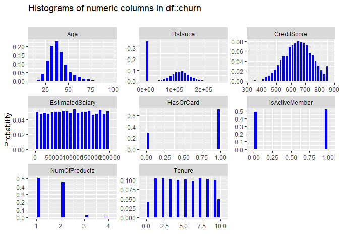

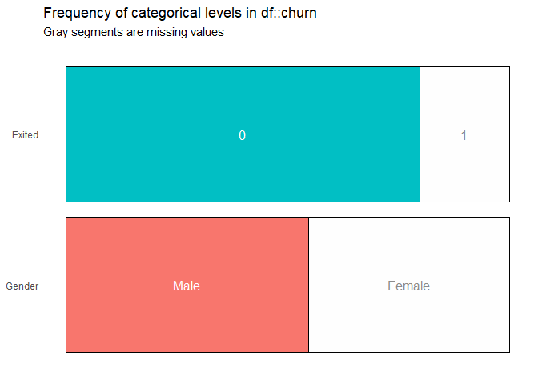

```r
cat <- inspect_cat(churn)
num <- inspect_num(churn)

show_plot(num); show_plot(cat)
```

Check proportion of target variabel

```r
prop.table(table(churn$Exited))
```

```
##
##      0      1
## 0.7963 0.2037
```

## Cross Validation

```r
set.seed(417)
index <- sample(nrow(churn), nrow(churn)*0.7)
train_churn <- churn[index, ]
test_churn <- churn[-index, ]
```

```r
prop.table(table(train_churn$Exited))
```

```
##
##         0         1
## 0.7958571 0.2041429
```

balancing the proportion

```r
glimpse(train_churn)
```

```
## Observations: 7,000
## Variables: 10
## $ CreditScore     <int> 660, 785, 561, 684, 757, 673, 781, 717, 500, 6...
## $ Gender          <fct> Male, Male, Male, Female, Female, Female, Male...
## $ Age             <int> 35, 36, 34, 34, 49, 57, 29, 42, 37, 27, 32, 46...
## $ Tenure          <int> 9, 2, 1, 6, 2, 4, 9, 5, 9, 1, 9, 7, 7, 7, 5, 1...
## $ Balance         <dbl> 113948.58, 0.00, 78829.53, 0.00, 0.00, 0.00, 0...
## $ NumOfProducts   <int> 1, 1, 1, 2, 2, 2, 2, 2, 1, 1, 2, 1, 1, 2, 2, 1...
## $ HasCrCard       <int> 1, 0, 1, 1, 0, 1, 0, 1, 1, 1, 0, 1, 1, 1, 1, 1...
## $ IsActiveMember  <int> 0, 1, 1, 1, 0, 1, 0, 0, 0, 0, 0, 0, 0, 0, 1, 1...
## $ EstimatedSalary <dbl> 188891.96, 61811.10, 12148.20, 130928.22, 1644...
## $ Exited          <fct> 1, 0, 0, 0, 0, 0, 0, 0, 0, 0, 0, 1, 1, 1, 0, 0...
```

```r
train_churn.new <- upSample(x = train_churn[, -11],
                            y = train_churn$Exited,
                            yname = "Exited")

prop.table(table(train_churn.new$Exited))
```

```
##
##   0   1
## 0.5 0.5
```

## Modelling from data train

```r
churn_model1 <- glm(Exited ~., train_churn.new, family = "binomial")
summary(churn_model1)
```

```
##
## Call:
## glm(formula = Exited ~ ., family = "binomial", data = train_churn.new)
##
## Deviance Residuals:
##      Min        1Q    Median        3Q       Max
## -2.74034  -0.96440  -0.01466   0.98195   2.50604
##
## Coefficients:
##                   Estimate Std. Error z value Pr(>|z|)
## (Intercept)     -2.512e+00  1.909e-01 -13.161  < 2e-16 ***
## CreditScore     -7.266e-04  2.169e-04  -3.349  0.00081 ***
## GenderMale      -5.730e-01  4.244e-02 -13.504  < 2e-16 ***
## Age              7.953e-02  2.256e-03  35.245  < 2e-16 ***
## Tenure          -2.862e-03  7.260e-03  -0.394  0.69344
## Balance          5.206e-06  3.513e-07  14.820  < 2e-16 ***
## NumOfProducts   -6.875e-02  3.141e-02  -2.189  0.02860 *
## HasCrCard        3.143e-02  4.649e-02   0.676  0.49900
## IsActiveMember  -8.763e-01  4.295e-02 -20.402  < 2e-16 ***
## EstimatedSalary  8.992e-07  3.674e-07   2.447  0.01439 *
## ---
## Signif. codes:  0 '***' 0.001 '**' 0.01 '*' 0.05 '.' 0.1 ' ' 1
##
## (Dispersion parameter for binomial family taken to be 1)
##
##     Null deviance: 15446  on 11141  degrees of freedom
## Residual deviance: 13082  on 11132  degrees of freedom
## AIC: 13102
##
## Number of Fisher Scoring iterations: 3
```

## Interpretation

Is Active member

```r
exp(-0.8763111832)
```

```
## [1] 0.4163158
```

interpretasi : memlalui nilai odds ratio diatas dapat diketahui bahwa user yang merupakan active member memiliki kemungkinan untuk exited 0.4x lebih kecil dibandingkan user yang bukan active member

Stepping the model

```r
stepAIC(churn_model1, direction = "backward")
```

```
## Start:  AIC=13102.2
## Exited ~ CreditScore + Gender + Age + Tenure + Balance + NumOfProducts +
##     HasCrCard + IsActiveMember + EstimatedSalary + Exited
```

```
##
## Step:  AIC=13102.2
## Exited ~ CreditScore + Gender + Age + Tenure + Balance + NumOfProducts +
##     HasCrCard + IsActiveMember + EstimatedSalary
##
##                   Df Deviance   AIC
## - Tenure           1    13082 13100
## - HasCrCard        1    13083 13101
## <none>                  13082 13102
## - NumOfProducts    1    13087 13105
## - EstimatedSalary  1    13088 13106
## - CreditScore      1    13093 13111
## - Gender           1    13267 13285
## - Balance          1    13306 13324
## - IsActiveMember   1    13512 13530
## - Age              1    14588 14606
##
## Step:  AIC=13100.36
## Exited ~ CreditScore + Gender + Age + Balance + NumOfProducts +
##     HasCrCard + IsActiveMember + EstimatedSalary
##
##                   Df Deviance   AIC
## - HasCrCard        1    13083 13099
## <none>                  13082 13100
## - NumOfProducts    1    13087 13103
## - EstimatedSalary  1    13088 13104
## - CreditScore      1    13094 13110
## - Gender           1    13267 13283
## - Balance          1    13306 13322
## - IsActiveMember   1    13512 13528
## - Age              1    14589 14605
##
## Step:  AIC=13098.81
## Exited ~ CreditScore + Gender + Age + Balance + NumOfProducts +
##     IsActiveMember + EstimatedSalary
##
##                   Df Deviance   AIC
## <none>                  13083 13099
## - NumOfProducts    1    13088 13102
## - EstimatedSalary  1    13089 13103
## - CreditScore      1    13094 13108
## - Gender           1    13267 13281
## - Balance          1    13306 13320
## - IsActiveMember   1    13515 13529
## - Age              1    14589 14603
```

```
##
## Call:  glm(formula = Exited ~ CreditScore + Gender + Age + Balance +
##     NumOfProducts + IsActiveMember + EstimatedSalary, family = "binomial",
##     data = train_churn.new)
##
## Coefficients:
##     (Intercept)      CreditScore       GenderMale              Age
##      -2.500e+00       -7.272e-04       -5.730e-01        7.951e-02
##         Balance    NumOfProducts   IsActiveMember  EstimatedSalary
##       5.203e-06       -6.981e-02       -8.772e-01        8.871e-07
##
## Degrees of Freedom: 11141 Total (i.e. Null);  11134 Residual
## Null Deviance:       15450
## Residual Deviance: 13080     AIC: 13100
```

```r
churn_model2 <- glm(formula = Exited ~ CreditScore + Gender + Age +
    Balance + NumOfProducts + IsActiveMember + EstimatedSalary,
    family = "binomial", data = train_churn.new)
```

# Predicting to data test (logisitic regression)

#### Model1 (all variables)

```r
test_churn$prob <- predict(churn_model1, test_churn, type = "response")
head(test_churn)
```

```
##    CreditScore Gender Age Tenure  Balance NumOfProducts HasCrCard
## 1          619 Female  42      2      0.0             1         1
## 4          699 Female  39      1      0.0             2         0
## 6          645   Male  44      8 113755.8             2         1
## 8          376 Female  29      4 115046.7             4         1
## 9          501   Male  44      4 142051.1             2         0
## 13         476 Female  34     10      0.0             2         1
##    IsActiveMember EstimatedSalary Exited      prob
## 1               1       101348.88      1 0.3893196
## 4               0        93826.63      0 0.5063372
## 6               0       149756.71      1 0.6325208
## 8               0       119346.88      1 0.4929993
## 9               1        74940.50      0 0.4579528
## 13              0        26260.98      0 0.4340549
```

menentukan threshold dari probabilty

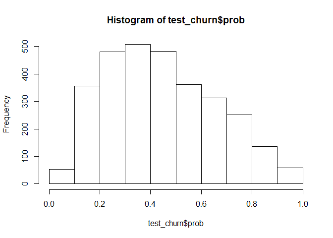

```r
hist(test_churn$prob)
```

threshold = 0.5

```r
test_churn$predict <- as.factor(ifelse(test_churn$prob >= 0.5, 1, 0))

head(test_churn)
```

```
##    CreditScore Gender Age Tenure  Balance NumOfProducts HasCrCard
## 1          619 Female  42      2      0.0             1         1
## 4          699 Female  39      1      0.0             2         0
## 6          645   Male  44      8 113755.8             2         1
## 8          376 Female  29      4 115046.7             4         1
## 9          501   Male  44      4 142051.1             2         0
## 13         476 Female  34     10      0.0             2         1
##    IsActiveMember EstimatedSalary Exited      prob predict
## 1               1       101348.88      1 0.3893196       0
## 4               0        93826.63      0 0.5063372       1
## 6               0       149756.71      1 0.6325208       1
## 8               0       119346.88      1 0.4929993       0
## 9               1        74940.50      0 0.4579528       0
## 13              0        26260.98      0 0.4340549       0
```

#### Model2 (stepAIC)

```r
test_churn$prob2 <- predict(churn_model2, test_churn, type = "response")

head(test_churn)
```

```
##    CreditScore Gender Age Tenure  Balance NumOfProducts HasCrCard
## 1          619 Female  42      2      0.0             1         1
## 4          699 Female  39      1      0.0             2         0
## 6          645   Male  44      8 113755.8             2         1
## 8          376 Female  29      4 115046.7             4         1
## 9          501   Male  44      4 142051.1             2         0
## 13         476 Female  34     10      0.0             2         1
##    IsActiveMember EstimatedSalary Exited      prob predict     prob2
## 1               1       101348.88      1 0.3893196       0 0.3851736
## 4               0        93826.63      0 0.5063372       1 0.5090860
## 6               0       149756.71      1 0.6325208       1 0.6321952
## 8               0       119346.88      1 0.4929993       0 0.4894184
## 9               1        74940.50      0 0.4579528       0 0.4625736
## 13              0        26260.98      0 0.4340549       0 0.4356141
```

threshold = 0.5

```r
test_churn$predict2 <- as.factor(ifelse(test_churn$prob2 >= 0.5, 1, 0))

head(test_churn)
```

```
##    CreditScore Gender Age Tenure  Balance NumOfProducts HasCrCard
## 1          619 Female  42      2      0.0             1         1
## 4          699 Female  39      1      0.0             2         0
## 6          645   Male  44      8 113755.8             2         1
## 8          376 Female  29      4 115046.7             4         1
## 9          501   Male  44      4 142051.1             2         0
## 13         476 Female  34     10      0.0             2         1
##    IsActiveMember EstimatedSalary Exited      prob predict     prob2
## 1               1       101348.88      1 0.3893196       0 0.3851736
## 4               0        93826.63      0 0.5063372       1 0.5090860
## 6               0       149756.71      1 0.6325208       1 0.6321952
## 8               0       119346.88      1 0.4929993       0 0.4894184
## 9               1        74940.50      0 0.4579528       0 0.4625736
## 13              0        26260.98      0 0.4340549       0 0.4356141
##    predict2
## 1         0
## 4         1
## 6         1
## 8         0
## 9         0
## 13        0
```

## Evaluating

Model1

```r
confusionMatrix(test_churn$predict, test_churn$Exited, positive = "1")
```

```
## Confusion Matrix and Statistics
##
##           Reference
## Prediction    0    1
##          0 1688  191
##          1  704  417
##
##                Accuracy : 0.7017
##                  95% CI : (0.6849, 0.718)
##     No Information Rate : 0.7973
##     P-Value [Acc > NIR] : 1
##
##                   Kappa : 0.2978
##
##  Mcnemar's Test P-Value : <2e-16
##
##             Sensitivity : 0.6859
##             Specificity : 0.7057
##          Pos Pred Value : 0.3720
##          Neg Pred Value : 0.8984
##              Prevalence : 0.2027
##          Detection Rate : 0.1390
##    Detection Prevalence : 0.3737
##       Balanced Accuracy : 0.6958
##
##        'Positive' Class : 1
##
```

Model2

```r
confusionMatrix(test_churn$predict2, test_churn$Exited, positive = "1")
```

```
## Confusion Matrix and Statistics
##
##           Reference
## Prediction    0    1
##          0 1681  191
##          1  711  417
##
##                Accuracy : 0.6993
##                  95% CI : (0.6826, 0.7157)
##     No Information Rate : 0.7973
##     P-Value [Acc > NIR] : 1
##
##                   Kappa : 0.2946
##
##  Mcnemar's Test P-Value : <2e-16
##
##             Sensitivity : 0.6859
##             Specificity : 0.7028
##          Pos Pred Value : 0.3697
##          Neg Pred Value : 0.8980
##              Prevalence : 0.2027
##          Detection Rate : 0.1390
##    Detection Prevalence : 0.3760
##       Balanced Accuracy : 0.6943
##
##        'Positive' Class : 1
##
```

# Predicting to data test (KNN)

```r
churn.n <- churn %>%
  mutate_if(is.numeric, scale) %>%
  select(-Gender)
```

## cross validation

```r
index2 <- sample(nrow(churn.n), nrow(churn.n)*0.7)
train_churn.n <- churn.n[index2,]
test_churn.n <- churn.n[-index2,]
```

## sampling data

```r
glimpse(train_churn.n)
```

```
## Observations: 7,000
## Variables: 9
## $ CreditScore     <dbl[,1]> <matrix[25 x 1]>
## $ Age             <dbl[,1]> <matrix[25 x 1]>
## $ Tenure          <dbl[,1]> <matrix[25 x 1]>
## $ Balance         <dbl[,1]> <matrix[25 x 1]>
## $ NumOfProducts   <dbl[,1]> <matrix[25 x 1]>
## $ HasCrCard       <dbl[,1]> <matrix[25 x 1]>
## $ IsActiveMember  <dbl[,1]> <matrix[25 x 1]>
## $ EstimatedSalary <dbl[,1]> <matrix[25 x 1]>
## $ Exited          <fct> 0, 0, 0, 0, 0, 0, 0, 0, 0, 0, 0, 0, 0, 1, 0, 0...
```

```r
train_churn.n <- upSample(x = train_churn.n[, -11],
                          y = train_churn.n$Exited,
                          yname = "Exited")

prop.table(table(train_churn.n$Exited))
```

```
##
##   0   1
## 0.5 0.5
```

## Modelling

```r
sqrt(nrow(train_churn.n))
```

```
## [1] 105.7639
```

k = 83

```r
pred_knn <- knn(train = train_churn.n[, -10],
                test = test_churn.n[, -10],
                cl = train_churn.n$Exited,
                k = 83)
```

k = 81

```r
pred_knn2 <- knn(train = train_churn.n[, -10],
                 test = test_churn.n[, -10],
                 cl = train_churn.n$Exited,
                 k = 81)
```

## Evaluating

k = 83

```r
confusionMatrix(pred_knn, test_churn.n$Exited, positive = "0")
```

```
## Confusion Matrix and Statistics
##
##           Reference
## Prediction    0    1
##          0 2257   57
##          1  113  573
##
##                Accuracy : 0.9433
##                  95% CI : (0.9345, 0.9513)
##     No Information Rate : 0.79
##     P-Value [Acc > NIR] : < 2.2e-16
##
##                   Kappa : 0.8346
##
##  Mcnemar's Test P-Value : 2.461e-05
##
##             Sensitivity : 0.9523
##             Specificity : 0.9095
##          Pos Pred Value : 0.9754
##          Neg Pred Value : 0.8353
##              Prevalence : 0.7900
##          Detection Rate : 0.7523
##    Detection Prevalence : 0.7713
##       Balanced Accuracy : 0.9309
##
##        'Positive' Class : 0
##
```

k = 81

```r
confusionMatrix(pred_knn2, test_churn.n$Exited, positive = "0")
```

```
## Confusion Matrix and Statistics
##
##           Reference
## Prediction    0    1
##          0 2255   58
##          1  115  572
##
##                Accuracy : 0.9423
##                  95% CI : (0.9334, 0.9504)
##     No Information Rate : 0.79
##     P-Value [Acc > NIR] : < 2.2e-16
##
##                   Kappa : 0.8318
##
##  Mcnemar's Test P-Value : 2.066e-05
##
##             Sensitivity : 0.9515
##             Specificity : 0.9079
##          Pos Pred Value : 0.9749
##          Neg Pred Value : 0.8326
##              Prevalence : 0.7900
##          Detection Rate : 0.7517
##    Detection Prevalence : 0.7710
##       Balanced Accuracy : 0.9297
##
##        'Positive' Class : 0
##
```

# Result

berdasarkan hasil evaluasi, maka saya menyimpulkan bahwa model churn prediction yang menggunakan KNN modelling memiliki tingkat ketepatan yang lebih baik dibaningkan dengan logistic regression.

Nilai akurasi yang dihasilkan oleh model dengan logistic regression baik model1 dan model2 (treshold = 5), hanya mendapatkan tingkat akurasi model di kisaran angka 70%, recall di kisaran angka 68% dan precision di kisaran angka 36%, membuat banyak prediksi yang salah dan berlawanan dengan actual.

Di sisi lain ketepatan model menggunakan KNN modelling mendapatkan nilai accuracy di angka 94%, recall 95% dan precision 97%, jauh diatas nilai model logistic. terlebih lagi churn prediction yang saya buat ini diharapkan dapat meningkatkan nilai precision agar dapat mengurangi resiko memprediksi customer tidak akan exited, padahal di kenyataan atau actual customer akan melakukan exited yang akan menimbulkan kerugian besar bagi perusahaan.